# Homework 6

Jake Hiltscher

## Data and Description

**Note that for the sake of length for this homework assignment, I am not having you check the model assumptions. You certainly can, if you would like, and in “real life” you would definitely need to do this prior to any statistical inference.**

Macroeconomists often speculate that life expectancy is linked with the economic well-being of a country. Macroeconomists also hypothesize that Organisation for Economic Co-operation and Development (OECD) (an international think tank charged with promoting policies that will improve global social and economic well-being) members will have longer life expectancy. To test these hypotheses, the LifeExpectancy.txt data set (found on Canvas) contains the following information:

| Variable | Description |
| --- | --- |
| LifeExp | Average life expectancy in years |
| Country | Country name |
| Group | Is the country a member of OECD, Africa, or other? |
| PPGDP | Per person GDP (on the log scale) |

The Group variable indicates if the country is a member of the OECD, a member of the African continent, or belonging to neither group (other). Note that the Country variable is just for your reference - you will not use this variable in your model.

Download LifeExpectancy.txt, and put it in the same folder as this R Markdown file.

#### 0. Replace the text “< PUT YOUR NAME HERE >” (above next to “author:”) with your full name.

#### 1. Read in the data set, call it “life”, remove the “Row” column, and change the class of any categorical variables to a factor. Print a summary of the data and make sure the data makes sense.

```r
life <- read_table("LifeExpectancy.txt") %>% select(-c("Row")) %>%
  mutate(Group = as.factor(Group))
head(life)
```

```
## # A tibble: 6 × 4
##   Country   Group PPGDP LifeExp
##   <chr>     <fct> <dbl>   <dbl>
## 1 Albania   other  8.21    75.3
## 2 Anguilla  other  9.53    79.2
## 3 Argentina other  9.12    77.7
## 4 Armenia   other  8.02    74.5
## 5 Aruba     other 10.0     79.8
## 6 Australia oecd  11.0     83.4
```

```r
summary(life)
```

```
##    Country             Group         PPGDP           LifeExp
##  Length:181         africa: 37   Min.   : 4.743   Min.   :51.86
##  Class :character   oecd  : 31   1st Qu.: 7.157   1st Qu.:70.81
##  Mode  :character   other :113   Median : 8.542   Median :75.29
##                                  Mean   : 8.492   Mean   :73.14
##                                  3rd Qu.: 9.844   3rd Qu.:79.80
##                                  Max.   :11.563   Max.   :85.62
```

#### 2. Create and print a scatterplot with the response on the $y$-axis and the other continuous variable on the $x$-axis. Comment on the the relationship between these two variables.

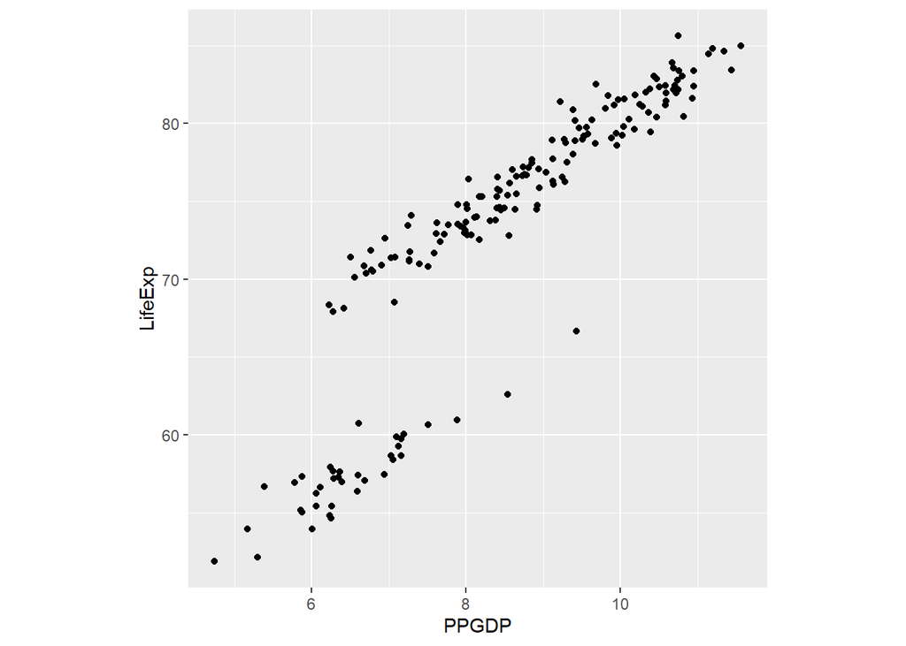

```r
ggplot(data = life) +
  geom_point(mapping = aes(x = PPGDP, y = LifeExp)) +
  theme(aspect.ratio = 1)
```

As PPGDP increases, LifeExp increases also. There is a positive linear relationship.

#### 3. Create and print a boxplot with the response on the $y$-axis and the categorical variable on the $x$-axis. Comment on the the relationship between these two variables.

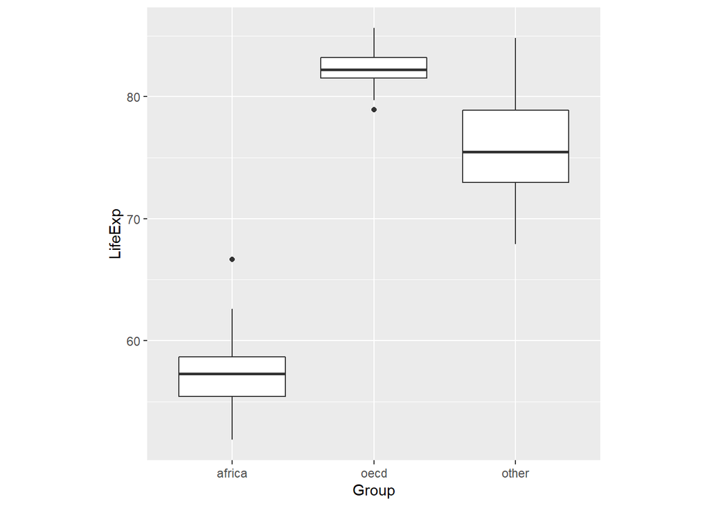

```r
ggplot(data = life) +
  geom_boxplot(mapping = aes(x = Group, y = LifeExp)) +
  theme(aspect.ratio = 1)
```

Life expectancy is lower in Africa compared to if a country is in the OECD or similar group.

#### 4. Create and print a color-coded scatterplot using all of the variables that will be in your model. Hint: plot the response on the $y$-axis, the other continuous variable on the $x$-axis, and color the points by the categorical variable.

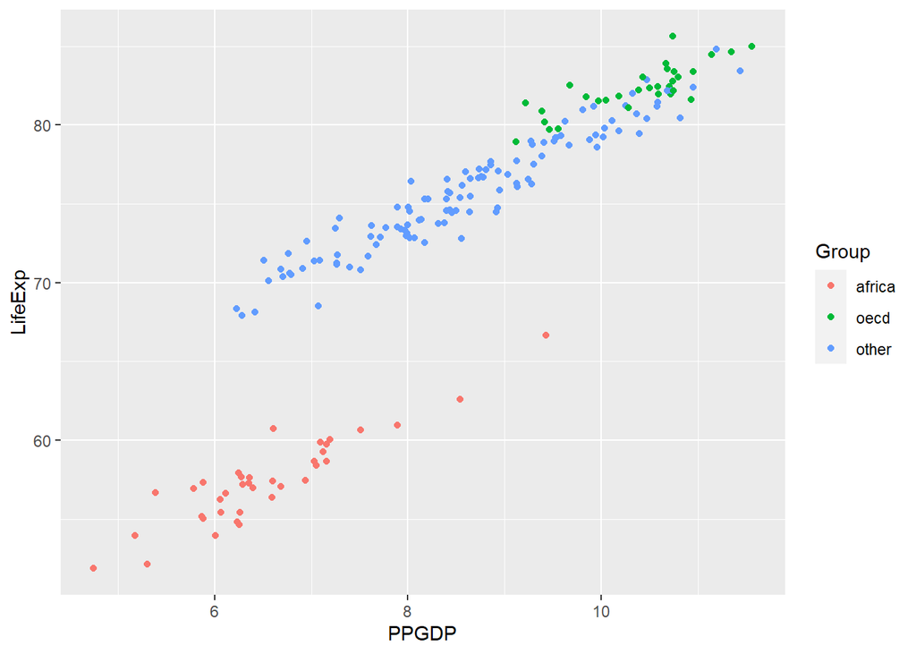

```r
ggplot(life, aes(PPGDP, LifeExp, color = Group)) +
  geom_point()
```

#### 5. Write out the general/theoretical model (using Greek letters/parameters) that you are thinking about applying to this data set (you will not write out the fitted model using coefficients, because you have not fit a model yet;)). DO NOT include interactions at this step. Remember, you will need to use dummy variables for Group. **USE “other” AS THE BASELINE CATEGORY**. Use variable names that are descriptive (not $y$, $x_1$, etc.).

$\text{LifeExp}_i)$ $=$ $\beta_0$ $+$ $\beta_1*$$\text{PPGDP}_i$ $-$ $\beta_2*$$I(\text{Group}_i = Africa)$ $+$ $\beta_3*$$I(\text{Group}_i = OECD)$

#### 6. Create dummy variables for the “africa” and “oecd” levels of Group.

```r
life$africa <- as.factor(ifelse(life$Group == "africa", 1,0))
life$oecd <- as.factor(ifelse(life$Group == "oecd", 1,0))
summary(life)
```

```
##    Country             Group         PPGDP           LifeExp      africa
##  Length:181         africa: 37   Min.   : 4.743   Min.   :51.86   0:144
##  Class :character   oecd  : 31   1st Qu.: 7.157   1st Qu.:70.81   1: 37
##  Mode  :character   other :113   Median : 8.542   Median :75.29
##                                  Mean   : 8.492   Mean   :73.14
##                                  3rd Qu.: 9.844   3rd Qu.:79.80
##                                  Max.   :11.563   Max.   :85.62
##  oecd
##  0:150
##  1: 31
##
##
##
##
```

#### 7. Fit a multiple linear regression model to the data (no transformations, interactions, etc.) **using the dummy variables you created**. *USE “other” AS THE BASELINE CATEGORY FOR GROUP*. Print a summary of the results.

```r
contrasts(life$Group)
```

```
##        oecd other
## africa    0     0
## oecd      1     0
## other     0     1
```

```r
life <- life %>% mutate(Group = relevel(Group, ref = "other"))

life_lm <- lm(LifeExp ~ PPGDP+africa+oecd, data = life)
summary(life_lm)
```

```
##
## Call:
## lm(formula = LifeExp ~ PPGDP + africa + oecd, data = life)
##
## Residuals:
##     Min      1Q  Median      3Q     Max
## -2.8136 -0.6546 -0.0327  0.6861  3.0454
##
## Coefficients:
##              Estimate Std. Error t value Pr(>|t|)
## (Intercept)  50.95789    0.65272  78.070  < 2e-16 ***
## PPGDP         2.87690    0.07478  38.470  < 2e-16 ***
## africa1     -12.29427    0.25726 -47.789  < 2e-16 ***
## oecd1         1.52983    0.25418   6.019 9.88e-09 ***
## ---
## Signif. codes:  0 '***' 0.001 '**' 0.01 '*' 0.05 '.' 0.1 ' ' 1
##
## Residual standard error: 1.077 on 177 degrees of freedom
## Multiple R-squared:  0.9857, Adjusted R-squared:  0.9855
## F-statistic:  4080 on 3 and 177 DF,  p-value: < 2.2e-16
```

#### 8. Briefly interpret the intercept (like we did in class). **Note that you will need to use the word “average” (or similar) twice since you are predicting an average already.** You will need to do this here and with the questions following, when interpreting.

The average average life expectancy of a individual living in a country not in Africa or a part of OECD as well as a PPGDP of 0 about 51 years.

#### 9. Briefly interpret the coefficient for PPGDP (log scale) (like we did in class). You do not need to un-transform anything - you can just write something like “per person GDP (log scale)” in your response.

As average PPGDP (log scale) increases by one, life expectancy increases by about 3 years, when a country is not in Africa or in OECD.

#### 10. For equal per person GDP (log scale), how does life expectancy change for countries that are members of the OECD compared to countries that are on the African continent? Show how you obtained this number, and briefly interpret this number (like we did in class).

The difference in life expectancy between members of OECD to countries that are on the African continent is around 14 years, with PPGDP held constant.

(1.52983 - -12.29427 = 13.8241)

#### 11. Create 95% confidence intervals for all coefficients (use the `confint` function).

```r
confint(life_lm, level = 0.95)
```

```
##                  2.5 %     97.5 %
## (Intercept)  49.669772  52.246000
## PPGDP         2.729321   3.024483
## africa1     -12.801967 -11.786572
## oecd1         1.028207   2.031453
```

#### 12. Briefly interpret the 95% confidence interval for I(Group=Africa).

We are 95% confident that the average life expectancy for individuals in African countries is between 11.79 and 12.80 years less than countries not in Africa or OECD.

#### 13. Use the `anova` function to conduct a hypothesis test that tests some coefficients simultaneously. Specifically, test if Group has a significant effect on LifeExp. What do you conclude from the result of the test? Hint: you will need to create another linear model and compare it with the one you made previously.

```r
life_compare <- life %>% select(-c(PPGDP))

life_compare_lm <- lm(LifeExp ~ Group, data = life_compare)
summary(life_compare_lm)
```

```
##
## Call:
## lm(formula = LifeExp ~ Group, data = life_compare)
##
## Residuals:
##     Min      1Q  Median      3Q     Max
## -7.8334 -2.2234 -0.1032  1.9566  9.2268
##
## Coefficients:
##             Estimate Std. Error t value Pr(>|t|)
## (Intercept)  75.7634     0.3092 244.997   <2e-16 ***
## Groupafrica -18.3201     0.6227 -29.423   <2e-16 ***
## Groupoecd     6.5292     0.6665   9.796   <2e-16 ***
## ---
## Signif. codes:  0 '***' 0.001 '**' 0.01 '*' 0.05 '.' 0.1 ' ' 1
##
## Residual standard error: 3.287 on 178 degrees of freedom
## Multiple R-squared:  0.8666, Adjusted R-squared:  0.8651
## F-statistic: 577.9 on 2 and 178 DF,  p-value: < 2.2e-16
```

```r
anova(life_compare_lm, life_lm)
```

```
## Analysis of Variance Table
##
## Model 1: LifeExp ~ Group
## Model 2: LifeExp ~ PPGDP + africa + oecd
##   Res.Df     RSS Df Sum of Sq      F    Pr(>F)
## 1    178 1923.52
## 2    177  205.48  1      1718 1479.9 < 2.2e-16 ***
## ---
## Signif. codes:  0 '***' 0.001 '**' 0.01 '*' 0.05 '.' 0.1 ' ' 1
```

#### 14. Create a 95% prediction interval for the average life expectancy of a country in the OECD with an average per person GDP (log scale) of 9.5. Print the result, and briefly interpret this interval (like we did in class). (Use the `predict` function.)

```r
predict(life_lm,
        newdata = data.frame(PPGDP = 9.5,
                             africa = "0",
                             oecd = "1"),
        level = 0.95,
        interval = "prediction")
```

```
##        fit      lwr      upr
## 1 79.81829 77.65424 81.98233
```

We are 95% confident that the life expectancy for a country in the OECD with a PPGDP of 9.5 will be between 78 and 82 years.

#### 15. Plot the fitted model on the scatterplot with the two continuous variables on the axes, colored by the categorical variable. Hint: you should have 3 different lines on your plot, and you will *not* need to have different line types or point shapes (you *will* need to have different colors).

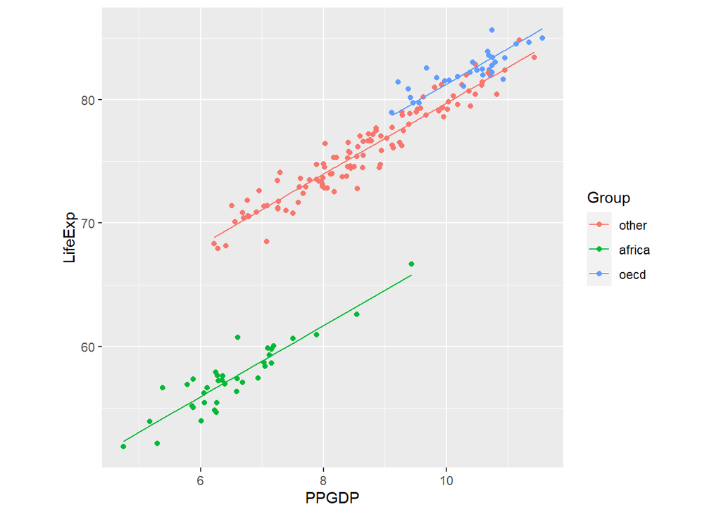

```r
ggplot(life) +
  geom_point(mapping = aes(x = PPGDP,
                           y = LifeExp,
                           color = Group)) +
  geom_line(mapping = aes(x = PPGDP,
                          y = predict(life_lm),
                          color = Group)) +
  theme(aspect.ratio = 1)
```

#### 16. Fit a multiple linear regression model to the data **using the dummy variables you created**, and include an interaction term between PPGDP and Group. *USE “other” AS THE BASELINE CATEGORY FOR GROUP*. Print a summary of the results.

```r
life_inter_lm <- lm(LifeExp ~ PPGDP + africa + oecd + PPGDP*africa +PPGDP*oecd, data = life)
summary(life_inter_lm)
```

```
##
## Call:
## lm(formula = LifeExp ~ PPGDP + africa + oecd + PPGDP * africa +
##     PPGDP * oecd, data = life)
##
## Residuals:
##     Min      1Q  Median      3Q     Max
## -2.7772 -0.6729 -0.1000  0.6446  3.0438
##
## Coefficients:
##                Estimate Std. Error t value Pr(>|t|)
## (Intercept)    50.42403    0.71286  70.734  < 2e-16 ***
## PPGDP           2.93882    0.08187  35.896  < 2e-16 ***
## africa1       -11.89511    1.47535  -8.063 1.13e-13 ***
## oecd1          11.29201    3.21337   3.514 0.000562 ***
## PPGDP:africa1  -0.04128    0.21249  -0.194 0.846187
## PPGDP:oecd1    -0.95268    0.31279  -3.046 0.002680 **
## ---
## Signif. codes:  0 '***' 0.001 '**' 0.01 '*' 0.05 '.' 0.1 ' ' 1
##
## Residual standard error: 1.056 on 175 degrees of freedom
## Multiple R-squared:  0.9865, Adjusted R-squared:  0.9861
## F-statistic:  2551 on 5 and 175 DF,  p-value: < 2.2e-16
```

#### 17. Write out the fitted model (using coefficients values from above) for a model with PPGDP, Group, and an interaction between PPGDG and Group. Remember, you will need to use dummy variables for Group. **USE “other” AS THE BASELINE CATEGORY**. Use variable names that are descriptive (not $y$, $x_1$, etc.).

$\text{LifeExp}_i)$ $=$ $50.424$ $+$ $2.94*$$\text{PPGDP}_i$ $-$ $11.9*$$I(\text{Group}_i = Africa)$ $+$ $11.29*$$I(\text{Group}_i = OECD)$ $-$ $0.04*$$\text{PPGDP:GroupAfrica}_i$ $-$ $0.95*$$\text{PPGDP:GroupOECD}_i$

#### 18. Use the `anova` function to test if the overall interaction between PPGDP and Group is significant. Print the result. What do you conclude?

```r
anova(life_inter_lm)
```

```
## Analysis of Variance Table
##
## Response: LifeExp
##               Df  Sum Sq Mean Sq    F value    Pr(>F)
## PPGDP          1 11555.6 11555.6 10363.9935 < 2.2e-16 ***
## africa         1  2611.3  2611.3  2342.0429 < 2.2e-16 ***
## oecd           1    42.1    42.1    37.7150 5.348e-09 ***
## PPGDP:africa   1     0.0     0.0     0.0129   0.90980
## PPGDP:oecd     1    10.3    10.3     9.2765   0.00268 **
## Residuals    175   195.1     1.1
## ---
## Signif. codes:  0 '***' 0.001 '**' 0.01 '*' 0.05 '.' 0.1 ' ' 1
```

The interaction between PPGDP and OECD is significant but PPGDP:Africa is not.

#### 19. Plot the fitted model (with the interaction included) on the scatterplot with the two continuous variables on the axes, colored by the categorical variable. Hint: you should have 3 different lines on your plot, and you will *not* need to have different line types or point shapes (you *will* need to have different colors).

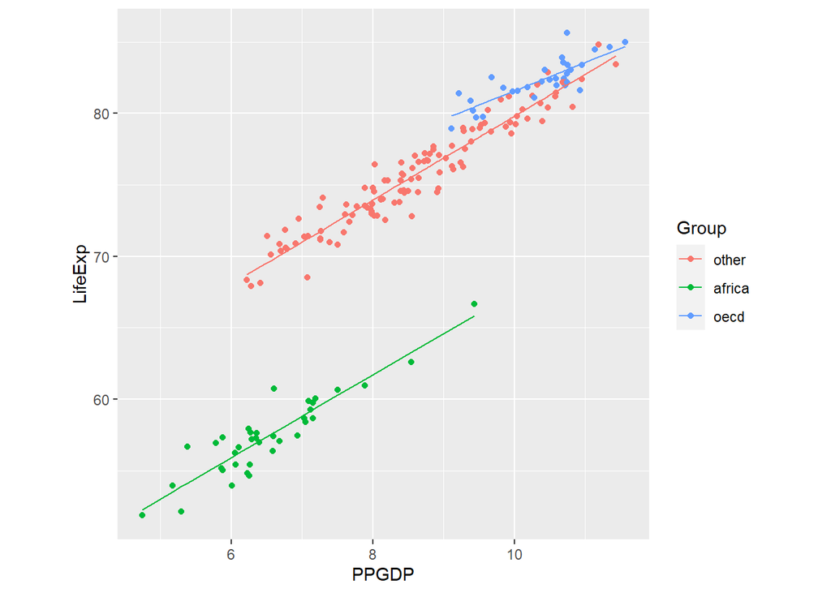

```r
ggplot(life) +
  geom_point(mapping = aes(x = PPGDP,
                           y = LifeExp,
                           color = Group)) +
  geom_line(mapping = aes(x = PPGDP,
                          y = predict(life_inter_lm),
                          color = Group)) +
  theme(aspect.ratio = 1)
```

#### 21. What is the effect of PPGDP on LifeExp for countries in a country other than those in the OECD or Africa (i.e. in the “other” category)? You should report a number in a complete sentence (as done in class toward the end of the notes). Since this is a continuous-categorical interaction, and since we are focusing on the effect of the continuous variable, you should use the “one unit increase” terminology in your response.

```r
# your code here, if needed
```

For countries not in OECD or Africa, if PPGDP increases by 1 unit, then we can expect an average change of 2.93 on life expectancy.

#### 22. What is the effect of PPGDP on LifeExp for countries in the OECD? You should report a number in a complete sentence (as done in class toward the end of the notes). Since this is a continuous-categorical interaction, and since we are focusing on the effect of the continuous variable, you should use the “one unit increase” terminology in your response.

```r
# your code here, if needed
```

#### 23. What is the effect of PPGDP on LifeExp for countries in Africa? You should report a number in a complete sentence (as done in class toward the end of the notes). Since this is a continuous-categorical interaction, and since we are focusing on the effect of the continuous variable, you should use the “one unit increase” terminology in your response.

```r
# your code here, if needed
```

#### 24. What is the effect of belonging to the OECD on LifeExp for countries with a PPGDP of 9? You should report a number in a complete sentence (as done in class toward the end of the notes).

For countries in OECD with a PPGDP of 9, we can expect a change of 2.72 on life expectancy.

#### 25. What is the effect of belonging to the OECD on LifeExp for countries with a PPGDP of 11? You should report a number in a complete sentence (as done in class toward the end of the notes).

```r
# your code here, if needed
```

#### 26. Briefly summarize what you learned, personally, from this analysis about the statistics, model fitting process, etc.

It’s interesting the difference between graphing the two different models can show a whole different story with interactions.

#### 27. Briefly summarize what you learned from this analysis *to a non-statistician*. Write a few sentences about (1) the purpose of this data set and analysis and (2) what you learned about this data set from your analysis. Write your response as if you were addressing a business manager (avoid using statistics jargon) and just provide the main take-aways.

This data set and analysis is to show if there is a relationship between countries being a member of OECD, in Africa, or neither, as well as PPGDP. We want to see if there is a relationship between these and Life Expectancy. There is a clear difference in life expectancy for countries in Africa and those that aren’t. As PPGDP increases, life expectancy increases across all groups.